# Crash Data 2023

STAT 133 - Project 2

Yuan Xie (3038930130)

# 2.1 Main content (about slide)

This analysis project is about the crash data in California during 2023 from the Statewide Integrated Traffic Records System (SWITRS). The data set is collected and maintained by the California Highway Patrol (CHP).

We will examine:

- Overall crash statistics
- Distribution and ranking tables
- Crashes involving pedestrians and bicyclists
- Exploratory research questions

## Data Import and Briefly Show the Data Structure

```r
library(tidyverse)
# use this code chunk to import your data
dat <- read_csv("crashes_2023.csv")
head(dat)
```

```
# A tibble: 6 × 21
   CASE_ID COLLISION_DATE MONTH  HOUR DAY_OF_WEEK COLLISION_SEVERITY
     <dbl> <date>         <dbl> <dbl>       <dbl> <chr>
1 81957564 2023-01-01         1     9           7 possible injury
2 81957983 2023-01-01         1     8           7 possible injury
3 81958138 2023-01-01         1    15           7 possible injury
4 81958139 2023-01-01         1     2           7 possible injury
5 81958141 2023-01-01         1    19           7 possible injury
6 81958156 2023-01-01         1    22           7 severe injury
# ℹ 15 more variables: NUMBER_KILLED <dbl>, NUMBER_INJURED <dbl>,
#   PCF_VIOL_CATEGORY <chr>, TYPE_OF_COLLISION <chr>,
#   PEDESTRIAN_ACCIDENT <chr>, BICYCLE_ACCIDENT <chr>,
#   MOTORCYCLE_ACCIDENT <chr>, COUNT_PED_INJURED <dbl>,
#   COUNT_BICYCLIST_INJURED <dbl>, COUNT_MC_INJURED <dbl>,
#   COUNT_PED_KILLED <dbl>, COUNT_BICYCLIST_KILLED <dbl>,
#   COUNT_MC_KILLED <dbl>, STWD_VEHTYPE_AT_FAULT <chr>, COUNTY <chr>
```

# 2.2 Overall Statistics

## Total Number of Crashes, Injured Victims and Fatal Victims

```r
overall_stats <- dat |>
  summarise(
    total_crashes = n(),
    total_injured = sum(NUMBER_INJURED, na.rm = TRUE),
    total_killed  = sum(NUMBER_KILLED, na.rm = TRUE)
  )

knitr::kable(overall_stats, caption = "Overall Statistics Data")
```

Overall Statistics Data

| total_crashes | total_injured | total_killed |
| --- | --- | --- |
| 161852 | 224642 | 3560 |

In 2023, there were **161852** crashes in California. These crashes resulted in **224642** injured victims and **3560** fatal victims.

# 2.3 Distribution Tables

## Counts and Percentages Per Month

```r
month_dist <- dat |>
  group_by(MONTH) |>
  summarise(count = n()) |>
  mutate(percent = round(count / sum(count) * 100, 2)) |>
  arrange(MONTH)

left  <- month_dist[1:6, ]
right <- month_dist[7:12, ]
```

```r
knitr::kable(left)
```

| MONTH | count | percent |
| --- | --- | --- |
| 1 | 12766 | 7.89 |
| 2 | 11793 | 7.29 |
| 3 | 13120 | 8.11 |
| 4 | 12987 | 8.02 |
| 5 | 13418 | 8.29 |
| 6 | 13256 | 8.19 |

```r
knitr::kable(right)
```

| MONTH | count | percent |
| --- | --- | --- |
| 7 | 13634 | 8.42 |
| 8 | 14715 | 9.09 |
| 9 | 14153 | 8.74 |
| 10 | 14974 | 9.25 |
| 11 | 13636 | 8.42 |
| 12 | 13400 | 8.28 |

## Counts and Percentages Per Day of Week

```r
day_dist <- dat |>
  group_by(DAY_OF_WEEK) |>
  summarise(count = n()) |>
  mutate(percent = round(count / sum(count) * 100, 2)) |>
  arrange(DAY_OF_WEEK)
knitr::kable(day_dist)
```

| DAY_OF_WEEK | count | percent |
| --- | --- | --- |
| 1 | 21647 | 13.37 |
| 2 | 23504 | 14.52 |
| 3 | 23845 | 14.73 |
| 4 | 23934 | 14.79 |
| 5 | 25478 | 15.74 |
| 6 | 22996 | 14.21 |
| 7 | 20448 | 12.63 |

## Counts and Percentages Per Day of Hour

```r
hour_dist <- dat |>
  group_by(HOUR) |>
  summarise(count = n()) |>
  mutate(percent = round(count / sum(count) * 100, 2)) |>
  arrange(HOUR)

h1 <- hour_dist[1:6, ]
h2 <- hour_dist[7:12, ]
h3 <- hour_dist[13:18, ]
h4 <- hour_dist[19:24, ]
```

See tables in the next slide.

| HOUR | count | percent |
| --- | --- | --- |
| 0 | 3552 | 2.19 |
| 1 | 3193 | 1.97 |
| 2 | 3031 | 1.87 |
| 3 | 2124 | 1.31 |
| 4 | 2215 | 1.37 |
| 5 | 3279 | 2.03 |

| HOUR | count | percent |
| --- | --- | --- |
| 6 | 4468 | 2.76 |
| 7 | 7211 | 4.46 |
| 8 | 8420 | 5.20 |
| 9 | 6472 | 4.00 |
| 10 | 6411 | 3.96 |
| 11 | 7223 | 4.46 |

| HOUR | count | percent |
| --- | --- | --- |
| 12 | 8362 | 5.17 |
| 13 | 8698 | 5.37 |
| 14 | 10249 | 6.33 |
| 15 | 11881 | 7.34 |
| 16 | 11461 | 7.08 |
| 17 | 12421 | 7.67 |

| HOUR | count | percent |
| --- | --- | --- |
| 18 | 10212 | 6.31 |
| 19 | 7779 | 4.81 |
| 20 | 6967 | 4.30 |
| 21 | 6166 | 3.81 |
| 22 | 5375 | 3.32 |
| 23 | 4682 | 2.89 |

# 2.4 Ranking Tables

## Top-10 PCF Violations

```r
top10_pcf <- dat |>
  group_by(PCF_VIOL_CATEGORY) |>
  summarise(count = n()) |>
  arrange(desc(count)) |>
  slice(1:10)

knitr::kable(top10_pcf)
```

| PCF_VIOL_CATEGORY | count |
| --- | --- |
| unsafe speed | 48018 |
| improper turning | 26804 |
| automobile right of way | 23465 |
| traffic signs | 15197 |
| DUI | 14635 |
| unsafe lane change | 6622 |
| unknown | 5114 |
| wrong side of road | 3932 |
| pedestrian right of way | 3910 |
| pedestrian violation | 3788 |

## Types of Collision Rank

```r
collision_rank <- dat |>
  group_by(TYPE_OF_COLLISION) |>
  summarise(count = n()) |>
  arrange(desc(count))

knitr::kable(collision_rank)
```

| TYPE_OF_COLLISION | count |
| --- | --- |
| rear end | 47294 |
| broadside | 43212 |
| hit object | 21753 |
| sideswipe | 18185 |
| head-on | 10535 |
| vehicle/pedestrian | 10438 |
| overturned | 6186 |
| other | 3592 |
| unknown | 657 |

## Top-8 Party At Fault

```r
top8_fault <- dat |>
  group_by(STWD_VEHTYPE_AT_FAULT) |>
  summarise(count = n()) |>
  arrange(desc(count)) |>
  slice(1:8)

knitr::kable(top8_fault)
```

| STWD_VEHTYPE_AT_FAULT | count |
| --- | --- |
| Passenger Car/Station Wagon | 107023 |
| Not Stated | 18653 |
| Pickup or Panel Truck | 15787 |
| Motorcycle/Scooter | 6470 |
| Bicycle | 4288 |
| Pedestrian | 3865 |
| Truck or Truck Tractor | 1684 |
| Truck or Truck Tractor with Trailer | 1298 |

# 2.5 Crashes Involving Pedestrians

## Number of Accidents Involving Pedestrians, Injured Pedestrians and Killed Pedestrians

```r
ped_accident <- dat |>
  filter(PEDESTRIAN_ACCIDENT == "yes") |>
  summarise(
    total_ped_crashes = n(),
    total_ped_injured = sum(COUNT_PED_INJURED, na.rm = TRUE),
    total_ped_killed  = sum(COUNT_PED_KILLED, na.rm = TRUE)
  )

knitr::kable(ped_accident, caption = "Pedestrian Statistics Data")
```

Pedestrian Statistics Data

| total_ped_crashes | total_ped_injured | total_ped_killed |
| --- | --- | --- |
| 11490 | 11022 | 974 |

There were **11490** crashes involving pedestrians. The crashes resulted in **11022** injured pedestrians and **974** pedestrian fatalities.

## Top-5 PCF Violations for Pedestrian Accidents

```r
top5_pcf_ped <- dat |>
  filter(PEDESTRIAN_ACCIDENT == "yes") |>
  group_by(PCF_VIOL_CATEGORY) |>
  summarise(count = n()) |>
  arrange(desc(count)) |>
  slice(1:5)

knitr::kable(top5_pcf_ped)
```

| PCF_VIOL_CATEGORY | count |
| --- | --- |
| pedestrian right of way | 3679 |
| pedestrian violation | 3654 |
| unsafe speed | 922 |
| unknown | 853 |
| improper turning | 653 |

## Top-5 Types of Collision for Pedestrian Accidents

```r
top5_collision_ped <- dat |>
  filter(PEDESTRIAN_ACCIDENT == "yes") |>
  group_by(TYPE_OF_COLLISION) |>
  summarise(count = n()) |>
  arrange(desc(count)) |>
  slice(1:5)

knitr::kable(top5_collision_ped)
```

| TYPE_OF_COLLISION | count |
| --- | --- |
| vehicle/pedestrian | 9897 |
| head-on | 401 |
| broadside | 338 |
| sideswipe | 321 |
| rear end | 254 |

## Top-5 Party at Fault for Pedestrian Accidents

```r
top5_fault_ped <- dat |>
  filter(PEDESTRIAN_ACCIDENT == "yes") |>
  group_by(STWD_VEHTYPE_AT_FAULT) |>
  summarise(count = n()) |>
  arrange(desc(count)) |>
  slice(1:5)

knitr::kable(top5_fault_ped)
```

| STWD_VEHTYPE_AT_FAULT | count |
| --- | --- |
| Passenger Car/Station Wagon | 4603 |
| Pedestrian | 3862 |
| Not Stated | 2040 |
| Pickup or Panel Truck | 689 |
| Truck or Truck Tractor | 77 |

# 2.6 Crashes Involving Bicyclists

## Number of Accidents Involving Bicyclists, Injured Bicyclists and Killed Bicyclists

```r
bic_accident <- dat |>
   filter(BICYCLE_ACCIDENT == "yes") |>
  summarise(
    total_bic_crashes = n(),
    total_bic_injured = sum(COUNT_BICYCLIST_INJURED, na.rm = TRUE),
    total_bic_killed  = sum(COUNT_BICYCLIST_KILLED, na.rm = TRUE)
  )

knitr::kable(bic_accident, caption = "Bicyclist Statistics Data")
```

Bicyclist Statistics Data

| total_bic_crashes | total_bic_injured | total_bic_killed |
| --- | --- | --- |
| 8744 | 8683 | 134 |

There were **8744** crashes involving bicyclists. The crashes resulted in **8683** injured bicyclists and **134** bicyclist fatalities.

## Top-5 PCF Violations for Bicyclist Accidents

```r
top5_pcf_bic <- dat |>
  filter(BICYCLE_ACCIDENT == "yes") |>
  group_by(PCF_VIOL_CATEGORY) |>
  summarise(count = n()) |>
  arrange(desc(count)) |>
  slice(1:5)

knitr::kable(top5_pcf_bic)
```

| PCF_VIOL_CATEGORY | count |
| --- | --- |
| automobile right of way | 1673 |
| wrong side of road | 1577 |
| improper turning | 1325 |
| traffic signs | 1081 |
| unsafe speed | 1000 |

## Top-5 Types of Collision for Bicyclist Accidents

```r
top5_collision_bic <- dat |>
  filter(BICYCLE_ACCIDENT == "yes") |>
  group_by(TYPE_OF_COLLISION) |>
  summarise(count = n()) |>
  arrange(desc(count)) |>
  slice(1:5)

knitr::kable(top5_collision_bic)
```

| TYPE_OF_COLLISION | count |
| --- | --- |
| broadside | 3896 |
| other | 1789 |
| sideswipe | 955 |
| head-on | 558 |
| rear end | 524 |

## Top-5 Party at Fault for Bicyclist Accidents

```r
top5_fault_bic <- dat |>
  filter(BICYCLE_ACCIDENT == "yes") |>
  group_by(STWD_VEHTYPE_AT_FAULT) |>
  summarise(count = n()) |>
  arrange(desc(count)) |>
  slice(1:5)

knitr::kable(top5_fault_bic)
```

| STWD_VEHTYPE_AT_FAULT | count |
| --- | --- |
| Bicycle | 4283 |
| Passenger Car/Station Wagon | 2399 |
| Not Stated | 1372 |
| Pickup or Panel Truck | 301 |
| Other Vehicle | 261 |

# 2.7 Exploratory Research Question

## Question: Is there a relationship between hour of the day and number of crashes?

```r
hour_summary <- dat |>
  group_by(HOUR) |>
  summarise(crashes = n())

ggplot(hour_summary, aes(x = HOUR, y = crashes)) +
  geom_col(fill = "steelblue") +
  labs(
    title = "Number of Crashes by Hour of Day",
    x = "Hour of Day",
    y = "Number of Crashes"
  )
```

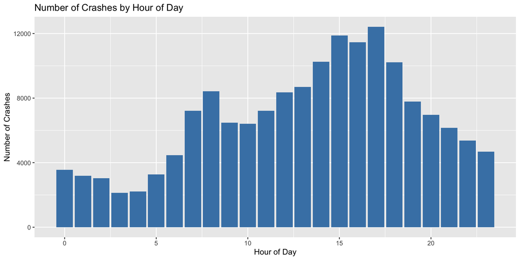

## Answer

Based on our data analysis and the bar chart plotted, it seems that there is some relationship between hour of the day and number of crashes. We can observe that:

- The number of crashes is the lowest during early morning hours, especially 3am and 4am.
- There is an substantial increase in crashes during the morning commute, especially 7am and 8 am.
- Most crashes happen in the late afternoon, around 4pm and 5pm.
- The number of crashes decreases gradually after 6pm.

# Thanks for your reading and patience!